# Association Rules Reveal Hidden Product Relationships in Online Retail

Ho Thi Hoang Nhu

# Introduction

In the dynamic and competitive world of online retail, **understanding the intricate language of customer behavior** is paramount for success (Smith, Jones & Brown, 2023). While traditional methods may focus on individual product selections, **customers often weave a fascinating narrative through their purchases**, combining items in unexpected yet insightful ways. This co-purchase behavior, revealing hidden relationships between seemingly disparate products, presents a valuable opportunity for businesses to gain a competitive edge.

**Association rule mining** emerges as a powerful tool for decoding this hidden language. This data mining technique allows us to unmask the intricate connections between products, unveiling patterns and trends that transcend individual purchases. By analyzing the tapestry of co-occurrences within customer transaction data, we can gain valuable insights into:

- **Complementary products**: Discovering frequently bought-together items that suggest natural pairings or needs fulfillment, such as purchasing printer ink alongside printer paper.
- **Substitute products**: Identifying products that serve similar purposes and are often purchased as alternatives, depending on factors like price or availability.
- **Category relationships**: Revealing connections between products within the same category, like different types of vegetables or beverages, potentially indicating broader purchasing habits or seasonal trends.

# My Objective in Project

This project delves into the application of association rule mining within the context of online retail. By analyzing customer purchase data, we aim to:

- **Identify hidden product relationships**: Discover frequently co-purchased items that go beyond what might be readily apparent, potentially revealing complementary products, substitute items, or related categories.
- **Uncover product clusters**: Group products that are frequently bought together, providing insights into customer preferences and shopping habits. This can help us understand how customers navigate product categories and identify potential upselling or bundling opportunities.

Through this exploration, we hope to contribute to the evolution of online retail by empowering businesses to better understand and cater to their customers' needs and preferences, ultimately fostering enhanced customer engagement, increased sales, and improved business strategies.

# Algorithms

[figure not shown]

> Table 1. Example set of baskets. *from* [Basket analysis and Association Rules](https://medium.com/@chyun55555/basket-analysis-and-association-rules-2c000d62e673)

## Referring the algorithm

From both *"Data Mining: Concepts and Techniques"* by Jiawei Han, Jian Pei, and Micheline Kamber, and the article "A Survey of Frequent Itemset Mining Algorithms" by Charu C. Aggarwal and Philip S. Yu, it becomes evident that the selection of association rule mining algorithms is intricately linked to the characteristics of the dataset.

In accordance with the findings presented in these sources:

- **For sparse datasets (many transactions with few items per transaction)**: FP-Growth can be more efficient due to its pattern-based approach and avoidance of candidate generation in later iterations.
- **For dense datasets (many items per transaction)**: Apriori might be preferable as it can leverage the monotonicity property for effective pruning.

## Apriori algorithm

The Apriori algorithm (Agrawal & Srikant, 1994) stands as a foundational pillar in the field of association rule mining, offering an iterative approach to identifying frequent itemsets upon which association rules are built.

[figure not shown]

> source: [Apriori](https://algobeans.com/2016/04/01/association-rules-and-the-apriori-algorithm/)

**Strengths of the Apriori Algorithm**

- **Simplicity and Understandability**: The Apriori algorithm is renowned for its intuitive and easy-to-understand design.
- **Data Scalability**: While less efficient for massive datasets compared to algorithms like FP-Growth, Apriori remains a viable option for small to medium-sized datasets.

## Fp-Growth Algorithm

The FP-Growth algorithm, introduced by Han, J., Pei, J., & Yin, Y. in their paper *"Mining Frequent Patterns without Candidate Generation,"* offers a novel approach to association rule mining. It employs a compact data structure called the FP-Tree to efficiently mine frequent patterns without the need for candidate generation. This innovative technique has gained widespread adoption due to its ability to handle large-scale datasets and deliver superior performance compared to traditional algorithms like Apriori.

[figure not shown]

> source: [fp-growth](https://psubnwell.github.io/2018/01/18/apriori-and-fp-growth/toy_dataset.png)

**Strengths of FP-Growth Algorithm**

The FP-Growth algorithm, as outlined by Han et al. (2000), possesses several strengths:

- **Efficiency**: eliminates candidate generation, resulting in significantly reduced computational overhead compared to traditional algorithms like Apriori.
- **Compact Data Representation**: The FP-Tree data structure enables efficient storage and traversal of transactional data, making FP-Growth well-suited for large datasets.
- **Scalability**: can handle massive datasets with millions of transactions and thousands of items, showcasing its scalability and robustness.
- **Parallelization**:can be parallelized for distributed processing across multiple computing nodes, further enhancing its scalability and efficiency.

## Some Applications of Algorithms

- **Market basket analysis**: Identifying frequently co-purchased items enables retailers to optimize product placement and recommend complementary products, ultimately enhancing customer experience and sales (Han, Pei & Kamber, 2011).
- **Customer segmentation**: Grouping customers based on their purchase patterns fosters targeted marketing campaigns and personalized recommendations (Han, Pei & Kamber, 2011).
- **Fraud detection**: Identifying unusual itemsets can aid in detecting fraudulent transactions (Han, Pei & Kamber, 2011).

## Understanding Support, Confidence, and Lift

Three fundamental computations in association rule mining are support, confidence, and lift:

- **Support (S):** Measures the frequency of an itemset within the dataset. It reflects how often a particular combination of items appears together.

  $$ support(A \rightarrow C) = support(A \cup C) \longrightarrow \: (range [0,1]) $$
- **Confidence (C):** Indicates the likelihood of the consequent (right-hand side) occurring, given the antecedent (left-hand side). High confidence implies a strong rule.

  $$ confidence(A \rightarrow C) = \frac{support(A \rightarrow C)}{support(A)} \longrightarrow \: (range [0,1]) $$
- **Lift (L):** Measures the strength of association between the antecedent and consequent, taking into account the overall frequency of the consequent. Lift greater than 1 suggests a positive association.

  $$ lift(A \rightarrow C) = \frac{confidence(A \rightarrow C)}{support(C)} \longrightarrow \: (range [0, \infty]) $$

# Dataset Selection

This dataset contains transactional data from 01/12/2010 to 09/12/2011 for a UK-based online retail business specializing in unique all-occasion gifts. The company's customer base includes wholesalers.

## Attributes

- InvoiceNo: Unique 6-digit transaction number. Prefix 'c' indicates cancellation.
- StockCode: Distinct 5-digit product code.
- Description: Nominal product name description.
- Quantity: Numeric, quantity of each product per transaction.
- InvoiceDate: Numeric timestamp indicating date and time of the invoice.
- UnitPrice: Numeric, price per unit in British pound sterling.
- CustomerID: Nominal, 5-digit unique customer identifier.
- Country: Nominal, name of the country where the customer resides.

## Importing Packages

```python
import numpy as np
import pandas as pd
import matplotlib.pyplot as plt
import seaborn as sns
%matplotlib inline
import warnings
warnings.filterwarnings("ignore")
from mlxtend.frequent_patterns import apriori, association_rules
import networkx as nx
```

## Loading Dataset

```python
df = pd.read_excel('~/Desktop/Online Retail.xlsx')
```

```python
df.head()
```

|  | InvoiceNo | StockCode | Description | Quantity | InvoiceDate | UnitPrice | CustomerID | Country |
| --- | --- | --- | --- | --- | --- | --- | --- | --- |
| 0 | 536365 | 85123A | WHITE HANGING HEART T-LIGHT HOLDER | 6 | 2010-12-01 08:26:00 | 2.55 | 17850.0 | United Kingdom |
| 1 | 536365 | 71053 | WHITE METAL LANTERN | 6 | 2010-12-01 08:26:00 | 3.39 | 17850.0 | United Kingdom |
| 2 | 536365 | 84406B | CREAM CUPID HEARTS COAT HANGER | 8 | 2010-12-01 08:26:00 | 2.75 | 17850.0 | United Kingdom |
| 3 | 536365 | 84029G | KNITTED UNION FLAG HOT WATER BOTTLE | 6 | 2010-12-01 08:26:00 | 3.39 | 17850.0 | United Kingdom |
| 4 | 536365 | 84029E | RED WOOLLY HOTTIE WHITE HEART. | 6 | 2010-12-01 08:26:00 | 3.39 | 17850.0 | United Kingdom |

```python
df.shape
```

```
(541909, 8)
```

Dataset Summary:

- Rows: 541,909
- Attributes: 8

```python
df.dtypes
```

```
InvoiceNo              object
StockCode              object
Description            object
Quantity                int64
InvoiceDate    datetime64[ns]
UnitPrice             float64
CustomerID            float64
Country                object
dtype: object
```

## EDA

```python
df.describe().T
```

|  | count | mean | min | 25% | 50% | 75% | max | std |
| --- | --- | --- | --- | --- | --- | --- | --- | --- |
| Quantity | 541909.0 | 9.55225 | -80995.0 | 1.0 | 3.0 | 10.0 | 80995.0 | 218.081158 |
| InvoiceDate | 541909 | 2011-07-04 13:34:57.156386048 | 2010-12-01 08:26:00 | 2011-03-28 11:34:00 | 2011-07-19 17:17:00 | 2011-10-19 11:27:00 | 2011-12-09 12:50:00 | NaN |
| UnitPrice | 541909.0 | 4.611114 | -11062.06 | 1.25 | 2.08 | 4.13 | 38970.0 | 96.759853 |
| CustomerID | 406829.0 | 15287.69057 | 12346.0 | 13953.0 | 15152.0 | 16791.0 | 18287.0 | 1713.600303 |

Key findings:

- Quantity distribution: The data reveals a right-skewed distribution for invoice quantities. This indicates that most invoices involve relatively small quantities, while a smaller number of invoices have significantly larger quantities.
- Median vs. mean: The median quantity (around 3) is considerably lower than the mean quantity (around 9.5). This difference suggests a positive skew, potentially influenced by a few outliers with exceptionally high quantities.
- Outliers: Both the minimum (-80,995) and maximum (80,995) quantities appear to be outliers. These negative and extremely high values might represent returns, adjustments, or exceptional bulk orders and require further investigation to ensure data accuracy and avoid skewing the analysis.
- Quartiles: Examining the quartiles, we see that 25% of invoices have quantities less than or equal to 1, while 75% have quantities less than or equal to 10. This further reinforces the predominance of smaller quantities compared to larger ones.

### Cleaning dataset

```python
print("duplicate data:",df.duplicated().value_counts())
print(df.isnull().sum())
```

```
duplicate data: False    536641
True       5268
Name: count, dtype: int64
InvoiceNo           0
StockCode           0
Description      1454
Quantity            0
InvoiceDate         0
UnitPrice           0
CustomerID     135080
Country             0
dtype: int64
```

```python
df.drop_duplicates(inplace=True)
```

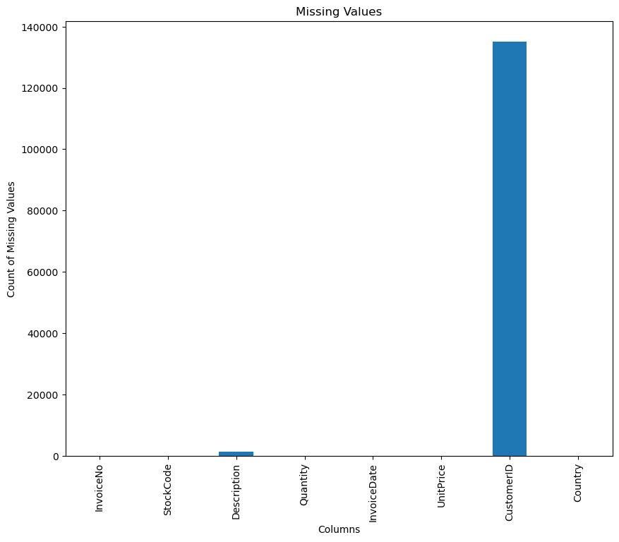

```python
plt.figure(figsize=(10, 8))
df.isnull().sum().plot(kind='bar')  # Use plot() method with kind='bar'
plt.title('Missing Values')
plt.xlabel('Columns')
plt.ylabel('Count of Missing Values')
plt.show()
```

```python
df.dropna(inplace=True)
print("the number of observasions after drop NA and duplicate values is: ",len(df))
```

```
the number of observasions after drop NA and duplicate values is:  401604
```

Based on the key findings, we have outliers for quatity (with negative number), maybe there's some problems in dataset and they make our dataset some wrong, now we double check them

### Checking dataset

```python
df['Quantity'].value_counts()
```

```
Quantity
 1        69605
 12       59828
 2        57425
 6        37480
 4        32093
          ...
 828          1
 560          1
-408          1
 512          1
-80995        1
Name: count, Length: 436, dtype: int64
```

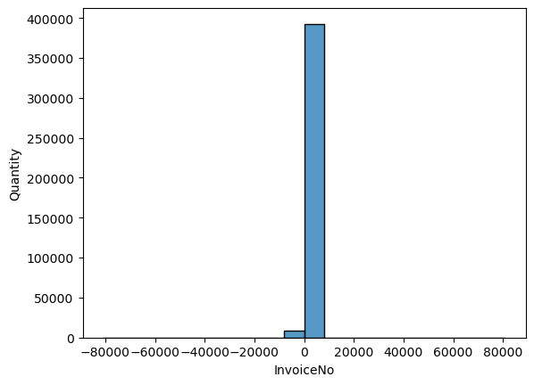

```python
sns.histplot(df['Quantity'], bins=20, palette='Purples')
plt.xlabel('InvoiceNo')
plt.ylabel('Quantity')


plt.show()
```

Dataset cannot quatity less than 0, so we focus on the bin having from 0 to less than 10000, so now we remove outliers where the Quantity column is less than or equal to 0 or greater than 10000.

```python
df = df[(df['Quantity'] > 0) & (df['Quantity'] <= 10000)]
```

```python
df.describe().T
```

|  | count | mean | min | 25% | 50% | 75% | max | std |
| --- | --- | --- | --- | --- | --- | --- | --- | --- |
| Quantity | 392729.0 | 12.726679 | 1.0 | 2.0 | 6.0 | 12.0 | 4800.0 | 43.086667 |
| InvoiceDate | 392729 | 2011-07-10 19:14:59.043156992 | 2010-12-01 08:26:00 | 2011-04-07 11:12:00 | 2011-07-31 12:02:00 | 2011-10-20 12:53:00 | 2011-12-09 12:50:00 | NaN |
| UnitPrice | 392729.0 | 3.125611 | 0.0 | 1.25 | 1.95 | 3.75 | 8142.75 | 22.240809 |
| CustomerID | 392729.0 | 15287.744536 | 12347.0 | 13955.0 | 15150.0 | 16791.0 | 18287.0 | 1713.563824 |

```python
df['Description'] = df['Description'].astype('category')
df['InvoiceNo'] = pd.to_numeric(df['InvoiceNo'], errors='coerce')


# Extracting date
df['year'] = df['InvoiceDate'].dt.year
df['month'] = df['InvoiceDate'].dt.month
df['day'] = df['InvoiceDate'].dt.day

#Extracting time
df['hour'] = df['InvoiceDate'].dt.hour


# Extracting weekday
df['weekday'] = df['InvoiceDate'].dt.weekday
df['weekday'] = df['weekday'].replace((0,1,2,3,4,5,6),
                                          ('Monday','Tuesday','Wednesday','Thursday','Friday','Saturday','Sunday'))
```

```python
df.head()
```

|  | InvoiceNo | StockCode | Description | Quantity | InvoiceDate | UnitPrice | CustomerID | Country | year | month | day | hour | weekday |
| --- | --- | --- | --- | --- | --- | --- | --- | --- | --- | --- | --- | --- | --- |
| 0 | 536365 | 85123A | WHITE HANGING HEART T-LIGHT HOLDER | 6 | 2010-12-01 08:26:00 | 2.55 | 17850.0 | United Kingdom | 2010 | 12 | 1 | 8 | Wednesday |
| 1 | 536365 | 71053 | WHITE METAL LANTERN | 6 | 2010-12-01 08:26:00 | 3.39 | 17850.0 | United Kingdom | 2010 | 12 | 1 | 8 | Wednesday |
| 2 | 536365 | 84406B | CREAM CUPID HEARTS COAT HANGER | 8 | 2010-12-01 08:26:00 | 2.75 | 17850.0 | United Kingdom | 2010 | 12 | 1 | 8 | Wednesday |
| 3 | 536365 | 84029G | KNITTED UNION FLAG HOT WATER BOTTLE | 6 | 2010-12-01 08:26:00 | 3.39 | 17850.0 | United Kingdom | 2010 | 12 | 1 | 8 | Wednesday |
| 4 | 536365 | 84029E | RED WOOLLY HOTTIE WHITE HEART. | 6 | 2010-12-01 08:26:00 | 3.39 | 17850.0 | United Kingdom | 2010 | 12 | 1 | 8 | Wednesday |

```python
print("Summary of year:",df['year'].value_counts())
```

```
Summary of year: year
2011    367056
2010     25673
Name: count, dtype: int64
```

### Exploring dataset

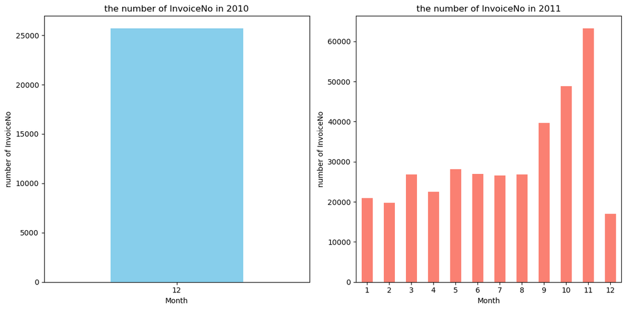

```python
invoice_count_2010 = df[df['year'] == 2010].groupby('month')['InvoiceNo'].count()
invoice_count_2011 = df[df['year'] == 2011].groupby('month')['InvoiceNo'].count()

# Plot
plt.figure(figsize=(12, 6))

plt.subplot(1, 2, 1)
invoice_count_2010.plot(kind='bar', color='skyblue')
plt.title('the number of InvoiceNo in 2010')
plt.xlabel('Month')
plt.ylabel('number of InvoiceNo')
plt.xticks(rotation=0)

plt.subplot(1, 2, 2)
invoice_count_2011.plot(kind='bar', color='salmon')
plt.title('the number of InvoiceNo in 2011')
plt.xlabel('Month')
plt.ylabel('number of InvoiceNo')
plt.xticks(rotation=0)

plt.tight_layout()
plt.show()
```

We can see just have for 1 month in 2010, we can not compare for other year, so I remove it and just keep year 2011

```python
df = df[df['year'] != 2010]
len(df)
```

```
367056
```

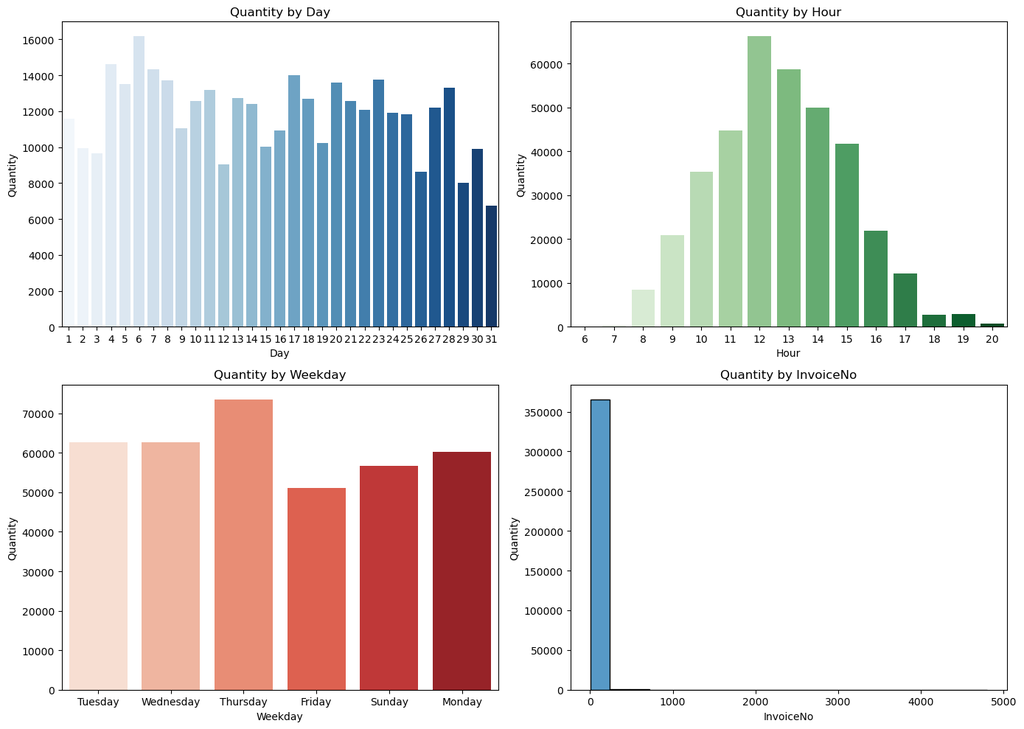

```python
fig, axes = plt.subplots(2, 2, figsize=(14, 10))

# Plot quantity by day
sns.countplot(x=df['day'], ax=axes[0, 0], palette='Blues')
axes[0, 0].set_title('Quantity by Day')
axes[0, 0].set_xlabel('Day')
axes[0, 0].set_ylabel('Quantity')

# Plot quantity by hour
sns.countplot(x=df['hour'], ax=axes[0, 1], palette='Greens')
axes[0, 1].set_title('Quantity by Hour')
axes[0, 1].set_xlabel('Hour')
axes[0, 1].set_ylabel('Quantity')

# Plot quantity by weekday
sns.countplot(x=df['weekday'], ax=axes[1, 0], palette='Reds')
axes[1, 0].set_title('Quantity by Weekday')
axes[1, 0].set_xlabel('Weekday')
axes[1, 0].set_ylabel('Quantity')

# Plot quantity
sns.histplot(df['Quantity'], bins=20, ax=axes[1, 1], palette='Purples')
axes[1, 1].set_title('Quantity by InvoiceNo')
axes[1, 1].set_xlabel('InvoiceNo')
axes[1, 1].set_ylabel('Quantity')

plt.tight_layout()
plt.show()
```

**Summary:**

**Insights:**

- **Sales strategy**: The information about peak sales months and times can be valuable for planning marketing campaigns and promotions. Targeting customers during these periods can potentially increase sales and revenue.
- **Resource allocation**: Understanding the peak purchase times can help businesses optimize staffing levels and resource allocation to ensure efficient customer service during high-traffic periods.
- **Customer behavior**: Analyzing the peak purchase day can provide insights into customer shopping habits and preferences. This information can be used to improve the overall customer experience and tailor offerings to meet specific needs.

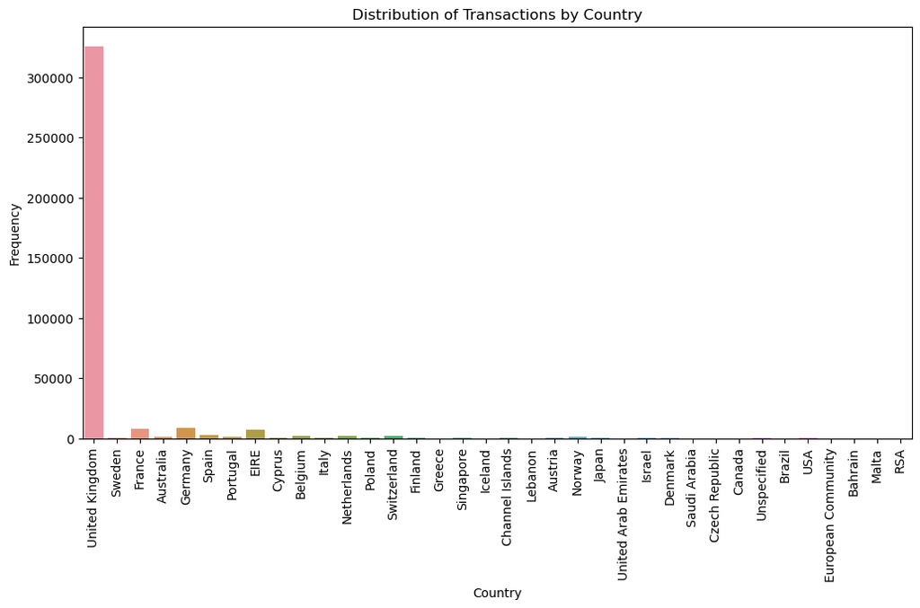

```python
plt.figure(figsize=(12,6))
sns.countplot(x="Country", data=df)
plt.ylabel('Frequency')
plt.xlabel('Country')
plt.xticks(rotation=90)
plt.title("Distribution of Transactions by Country")
plt.show()
```

Focusing on the UK's data aligns with the project's goal of finding association rules (frequent item purchases). This nation dominates the dataset, offering a strong foundation for discovering connections in buying habits.

# Data Transformation

In association rule mining algorithms, it's common to represent item presence in transactions using binary values (0 or 1). This simplifies calculations and reduces memory usage compared to working with raw item names or IDs.

```python
# Filter rows where Country is "United Kingdom",
#then group by 'InvoiceNo' and 'Description' and sum up 'Quantity'
itemset = df[df['Country'] == "United Kingdom"]\
            .groupby(['InvoiceNo', 'Description'])["Quantity"]\
            .sum().unstack().reset_index() \
            .set_index("InvoiceNo")


itemset.head()
```

| Description InvoiceNo | 4 PURPLE FLOCK DINNER CANDLES | 50'S CHRISTMAS GIFT BAG LARGE | DOLLY GIRL BEAKER | I LOVE LONDON MINI BACKPACK | I LOVE LONDON MINI RUCKSACK | NINE DRAWER OFFICE TIDY | OVAL WALL MIRROR DIAMANTE | RED SPOT GIFT BAG LARGE | SET 2 TEA TOWELS I LOVE LONDON | SPACEBOY BABY GIFT SET | ... | ZINC STAR T-LIGHT HOLDER | ZINC SWEETHEART SOAP DISH | ZINC SWEETHEART WIRE LETTER RACK | ZINC T-LIGHT HOLDER STAR LARGE | ZINC T-LIGHT HOLDER STARS LARGE | ZINC T-LIGHT HOLDER STARS SMALL | ZINC TOP 2 DOOR WOODEN SHELF | ZINC WILLIE WINKIE CANDLE STICK | ZINC WIRE KITCHEN ORGANISER | ZINC WIRE SWEETHEART LETTER TRAY |
| --- | --- | --- | --- | --- | --- | --- | --- | --- | --- | --- | --- | --- | --- | --- | --- | --- | --- | --- | --- | --- | --- |
| 539993 | 0 | 0 | 0 | 0 | 0 | 0 | 0 | 0 | 0 | 0 | ... | 0 | 0 | 0 | 0 | 0 | 0 | 0 | 0 | 0 | 0 |
| 540001 | 0 | 0 | 0 | 0 | 0 | 0 | 0 | 0 | 0 | 0 | ... | 0 | 0 | 0 | 0 | 0 | 0 | 0 | 0 | 0 | 0 |
| 540002 | 0 | 0 | 0 | 0 | 0 | 0 | 0 | 0 | 0 | 0 | ... | 0 | 0 | 0 | 0 | 0 | 0 | 0 | 0 | 0 | 0 |
| 540003 | 0 | 0 | 0 | 0 | 0 | 0 | 0 | 0 | 0 | 0 | ... | 0 | 0 | 0 | 0 | 0 | 0 | 0 | 0 | 0 | 0 |
| 540004 | 0 | 0 | 0 | 0 | 0 | 0 | 0 | 0 | 0 | 0 | ... | 0 | 0 | 0 | 0 | 0 | 0 | 0 | 0 | 0 | 0 |

5 rows × 3876 columns

```python
itemset_coded = itemset.applymap(lambda x: 1 if x >= 1 else 0)
```

Association rules primarily aim to discover patterns of co-occurrence between multiple items purchased together. Filtering out invoices with only 1 item eliminates them from the analysis as they don't offer any insights into relationships between different products.

Most association rule mining algorithms utilize a minimum support threshold. This threshold defines the minimum number of times an itemset (group of items) needs to appear in the data to be considered "frequent" and eligible for further analysis as a potential rule. Filtering for invoices with 2+ items ensures that we have a sufficient number of items per transaction to potentially discover frequent itemsets that meet the minimum support requirement.

```python
filtered_itemset = itemset_coded[itemset_coded.sum(axis=1) >= 2]
```

```python
filtered_itemset
```

| Description InvoiceNo | 4 PURPLE FLOCK DINNER CANDLES | 50'S CHRISTMAS GIFT BAG LARGE | DOLLY GIRL BEAKER | I LOVE LONDON MINI BACKPACK | I LOVE LONDON MINI RUCKSACK | NINE DRAWER OFFICE TIDY | OVAL WALL MIRROR DIAMANTE | RED SPOT GIFT BAG LARGE | SET 2 TEA TOWELS I LOVE LONDON | SPACEBOY BABY GIFT SET | ... | ZINC STAR T-LIGHT HOLDER | ZINC SWEETHEART SOAP DISH | ZINC SWEETHEART WIRE LETTER RACK | ZINC T-LIGHT HOLDER STAR LARGE | ZINC T-LIGHT HOLDER STARS LARGE | ZINC T-LIGHT HOLDER STARS SMALL | ZINC TOP 2 DOOR WOODEN SHELF | ZINC WILLIE WINKIE CANDLE STICK | ZINC WIRE KITCHEN ORGANISER | ZINC WIRE SWEETHEART LETTER TRAY |
| --- | --- | --- | --- | --- | --- | --- | --- | --- | --- | --- | --- | --- | --- | --- | --- | --- | --- | --- | --- | --- | --- |
| 539993 | 0 | 0 | 0 | 0 | 0 | 0 | 0 | 0 | 0 | 0 | ... | 0 | 0 | 0 | 0 | 0 | 0 | 0 | 0 | 0 | 0 |
| 540001 | 0 | 0 | 0 | 0 | 0 | 0 | 0 | 0 | 0 | 0 | ... | 0 | 0 | 0 | 0 | 0 | 0 | 0 | 0 | 0 | 0 |
| 540002 | 0 | 0 | 0 | 0 | 0 | 0 | 0 | 0 | 0 | 0 | ... | 0 | 0 | 0 | 0 | 0 | 0 | 0 | 0 | 0 | 0 |
| 540003 | 0 | 0 | 0 | 0 | 0 | 0 | 0 | 0 | 0 | 0 | ... | 0 | 0 | 0 | 0 | 0 | 0 | 0 | 0 | 0 | 0 |
| 540005 | 0 | 0 | 0 | 0 | 0 | 0 | 0 | 0 | 0 | 0 | ... | 0 | 0 | 0 | 0 | 0 | 0 | 0 | 0 | 0 | 0 |
| ... | ... | ... | ... | ... | ... | ... | ... | ... | ... | ... | ... | ... | ... | ... | ... | ... | ... | ... | ... | ... | ... |
| 581582 | 0 | 0 | 0 | 0 | 0 | 0 | 0 | 0 | 0 | 0 | ... | 0 | 0 | 0 | 0 | 0 | 0 | 0 | 0 | 0 | 0 |
| 581583 | 0 | 0 | 0 | 0 | 0 | 0 | 0 | 0 | 0 | 0 | ... | 0 | 0 | 0 | 0 | 0 | 0 | 0 | 0 | 0 | 0 |
| 581584 | 0 | 0 | 0 | 0 | 0 | 0 | 0 | 0 | 0 | 0 | ... | 0 | 0 | 0 | 0 | 0 | 0 | 0 | 0 | 0 | 0 |
| 581585 | 0 | 0 | 0 | 0 | 0 | 0 | 0 | 0 | 0 | 0 | ... | 0 | 0 | 0 | 1 | 0 | 0 | 0 | 1 | 0 | 0 |
| 581586 | 0 | 0 | 0 | 0 | 0 | 0 | 0 | 0 | 0 | 0 | ... | 0 | 0 | 0 | 0 | 0 | 0 | 0 | 0 | 0 | 0 |

14210 rows × 3876 columns

We have 14210 transactions with 3876 items

# Generating Frequent Itemsets

**Frequent itemsets**, the cornerstone of association rule mining, represent groups of items that frequently appear together in transactions within a dataset. Uncovering these frequent patterns helps identify potential associations between items, providing valuable insights into customer buying habits and product relationships.

## Referring the suitable algorithm

```python
itemset_coded.sum(axis=1).mean()
```

```
20.92328231846304
```

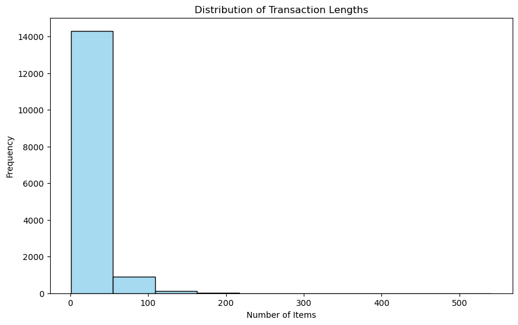

```python
transaction_lengths = itemset_coded.sum(axis=1)

# Plot
plt.figure(figsize=(10, 6))
sns.histplot(transaction_lengths, bins=10, color='skyblue', edgecolor='black')
plt.title('Distribution of Transaction Lengths')
plt.xlabel('Number of Items')
plt.ylabel('Frequency')
plt.show()
```

**My Recommendation:**

**Apriori** might be a more suitable algorithm for generating frequent itemsets. This is because:

- Apriori can leverage the monotonicity property for effective pruning, which can be particularly beneficial for dense datasets.
- FP-Growth, while efficient for sparse datasets, might not offer significant advantages in this case due to the high number of items per transaction.

## Setting the Parameters for Apriori

**Support:**

- At first, I want to test with **support = 0.03**, means that itemset is considered frequent if it appears in at least 3% (426 transactions) of all transactions in dataset.Interesting findings at this threshold might reveal popular product combinations or frequently occurring purchasing patterns among customers.
- Then, I use **support = 0.01** means that Lowering the support threshold to 0.01 expands our search to identify additional interesting patterns in the dataset, requiring itemsets to be present in at least 1% of all transactions (equivalent to 142 transactions).

**metric="lift":**

# Apriori Algorithm min_support=0.03

```python
apriori_itemsets_test = apriori(filtered_itemset, min_support=0.03,use_colnames=True)
```

```python
apriori_itemsets_test['itemsets'].apply(lambda x: len(x)).value_counts()
```

```
itemsets
1    103
2      5
Name: count, dtype: int64
```

```python
apriori_itemsets_test.sort_values("support", ascending=False)
```

|  | support | itemsets |
| --- | --- | --- |
| 98 | 0.117664 | (WHITE HANGING HEART T-LIGHT HOLDER) |
| 40 | 0.095567 | (JUMBO BAG RED RETROSPOT) |
| 78 | 0.089444 | (REGENCY CAKESTAND 3 TIER) |
| 69 | 0.088459 | (PARTY BUNTING) |
| 6 | 0.085222 | (ASSORTED COLOUR BIRD ORNAMENT) |
| ... | ... | ... |
| 30 | 0.030401 | (HOT WATER BOTTLE TEA AND SYMPATHY) |
| 16 | 0.030331 | (DOORMAT UNION FLAG) |
| 95 | 0.030120 | (TRAVEL CARD WALLET KEEP CALM) |
| 83 | 0.030049 | (SET OF 3 BUTTERFLY COOKIE CUTTERS) |
| 48 | 0.030049 | (LOVE HOT WATER BOTTLE) |

108 rows × 2 columns

```python
apriori_itemsets_test['length'] = apriori_itemsets_test['itemsets'].apply(lambda x: len(x))
```

```python
apriori_itemsets_test.sort_values(by='support', ascending=False)
```

|  | support | itemsets | length |
| --- | --- | --- | --- |
| 98 | 0.117664 | (WHITE HANGING HEART T-LIGHT HOLDER) | 1 |
| 40 | 0.095567 | (JUMBO BAG RED RETROSPOT) | 1 |
| 78 | 0.089444 | (REGENCY CAKESTAND 3 TIER) | 1 |
| 69 | 0.088459 | (PARTY BUNTING) | 1 |
| 6 | 0.085222 | (ASSORTED COLOUR BIRD ORNAMENT) | 1 |
| ... | ... | ... | ... |
| 30 | 0.030401 | (HOT WATER BOTTLE TEA AND SYMPATHY) | 1 |
| 16 | 0.030331 | (DOORMAT UNION FLAG) | 1 |
| 95 | 0.030120 | (TRAVEL CARD WALLET KEEP CALM) | 1 |
| 83 | 0.030049 | (SET OF 3 BUTTERFLY COOKIE CUTTERS) | 1 |
| 48 | 0.030049 | (LOVE HOT WATER BOTTLE) | 1 |

108 rows × 3 columns

```python
apriori_itemsets_test[apriori_itemsets_test["length"] > 1]
```

|  | support | itemsets | length |
| --- | --- | --- | --- |
| 103 | 0.032231 | (GARDENERS KNEELING PAD KEEP CALM , GARDENERS ... | 2 |
| 104 | 0.031949 | (ROSES REGENCY TEACUP AND SAUCER , GREEN REGEN... | 2 |
| 105 | 0.034131 | (JUMBO BAG RED RETROSPOT, JUMBO BAG PINK POLKA... | 2 |
| 106 | 0.032583 | (LUNCH BAG RED RETROSPOT, LUNCH BAG BLACK SKU... | 2 |
| 107 | 0.032020 | (LUNCH BAG PINK POLKADOT, LUNCH BAG RED RETROS... | 2 |

```python
apriori_rules_test = association_rules(apriori_itemsets_test, metric='confidence', min_threshold=0.3)\
    .sort_values("support",ascending=False)
apriori_rules_test.describe().T
```

|  | count | mean | std | min | 25% | 50% | 75% | max |
| --- | --- | --- | --- | --- | --- | --- | --- | --- |
| antecedent support | 10.0 | 0.060837 | 0.017423 | 0.040957 | 0.046763 | 0.056263 | 0.073452 | 0.095567 |
| consequent support | 10.0 | 0.060837 | 0.017423 | 0.040957 | 0.046763 | 0.056263 | 0.073452 | 0.095567 |
| support | 10.0 | 0.032583 | 0.000848 | 0.031949 | 0.032020 | 0.032231 | 0.032583 | 0.034131 |
| confidence | 10.0 | 0.571633 | 0.144703 | 0.357143 | 0.444865 | 0.586143 | 0.688712 | 0.780069 |
| lift | 10.0 | 10.333723 | 4.750741 | 6.442330 | 6.523136 | 7.325780 | 14.030302 | 17.347068 |
| leverage | 10.0 | 0.028823 | 0.001150 | 0.027525 | 0.027649 | 0.028899 | 0.029934 | 0.030108 |
| conviction | 10.0 | 2.471124 | 0.962646 | 1.470389 | 1.680114 | 2.237502 | 3.110196 | 4.342410 |
| zhangs_metric | 10.0 | 0.942240 | 0.034919 | 0.895742 | 0.914548 | 0.935166 | 0.977746 | 0.986725 |

We can observe that there are 10 rules generated here.

Next, we will select the top 5 most confidence and the top 5 highest lift rules.

```python
apriori_rules_test.sort_values(ascending=False,by="confidence").head(5)
```

|  | antecedents | consequents | antecedent support | consequent support | support | confidence | lift | leverage | conviction | zhangs_metric |
| --- | --- | --- | --- | --- | --- | --- | --- | --- | --- | --- |
| 3 | (GREEN REGENCY TEACUP AND SAUCER) | (ROSES REGENCY TEACUP AND SAUCER ) | 0.040957 | 0.044968 | 0.031949 | 0.780069 | 17.347068 | 0.030108 | 4.342410 | 0.982598 |
| 1 | (GARDENERS KNEELING PAD CUP OF TEA ) | (GARDENERS KNEELING PAD KEEP CALM ) | 0.044053 | 0.052146 | 0.032231 | 0.731629 | 14.030302 | 0.029934 | 3.531883 | 0.971525 |
| 2 | (ROSES REGENCY TEACUP AND SAUCER ) | (GREEN REGENCY TEACUP AND SAUCER) | 0.044968 | 0.040957 | 0.031949 | 0.710485 | 17.347068 | 0.030108 | 3.312586 | 0.986725 |
| 5 | (JUMBO BAG PINK POLKADOT) | (JUMBO BAG RED RETROSPOT) | 0.054750 | 0.095567 | 0.034131 | 0.623393 | 6.523136 | 0.028899 | 2.401533 | 0.895742 |
| 0 | (GARDENERS KNEELING PAD KEEP CALM ) | (GARDENERS KNEELING PAD CUP OF TEA ) | 0.052146 | 0.044053 | 0.032231 | 0.618084 | 14.030302 | 0.029934 | 2.503026 | 0.979820 |

Rule 1: (GREEN REGENCY TEACUP AND SAUCER) -> (ROSES REGENCY TEACUP AND SAUCER)

- Customers who buy a GREEN REGENCY TEACUP AND SAUCER are 78.01% likely to also buy a ROSES REGENCY TEACUP AND SAUCER (confidence). This association is 17.35 times stronger than what one would expect by chance (lift).

Rule 2: (GARDENERS KNEELING PAD CUP OF TEA) -> (GARDENERS KNEELING PAD KEEP CALM)

- Customers who buy a ARDENERS KNEELING PAD CUP OF TEA are 73.16% likely to also buy GARDENERS KNEELING PAD KEEP CALM (confidence). This association is 14.03 times stronger than expected by chance (lift).

```python
apriori_rules_test.sort_values(ascending=False,by="lift").head(5)
```

|  | antecedents | consequents | antecedent support | consequent support | support | confidence | lift | leverage | conviction | zhangs_metric |
| --- | --- | --- | --- | --- | --- | --- | --- | --- | --- | --- |
| 2 | (ROSES REGENCY TEACUP AND SAUCER ) | (GREEN REGENCY TEACUP AND SAUCER) | 0.044968 | 0.040957 | 0.031949 | 0.710485 | 17.347068 | 0.030108 | 3.312586 | 0.986725 |
| 3 | (GREEN REGENCY TEACUP AND SAUCER) | (ROSES REGENCY TEACUP AND SAUCER ) | 0.040957 | 0.044968 | 0.031949 | 0.780069 | 17.347068 | 0.030108 | 4.342410 | 0.982598 |
| 0 | (GARDENERS KNEELING PAD KEEP CALM ) | (GARDENERS KNEELING PAD CUP OF TEA ) | 0.052146 | 0.044053 | 0.032231 | 0.618084 | 14.030302 | 0.029934 | 2.503026 | 0.979820 |
| 1 | (GARDENERS KNEELING PAD CUP OF TEA ) | (GARDENERS KNEELING PAD KEEP CALM ) | 0.044053 | 0.052146 | 0.032231 | 0.731629 | 14.030302 | 0.029934 | 3.531883 | 0.971525 |
| 9 | (LUNCH BAG RED RETROSPOT) | (LUNCH BAG PINK POLKADOT) | 0.075651 | 0.057776 | 0.032020 | 0.423256 | 7.325780 | 0.027649 | 1.633694 | 0.934166 |

```python
apriori_rules_test.sort_values(by=['support', 'confidence', 'lift'], ascending = False).head(5)
```

|  | antecedents | consequents | antecedent support | consequent support | support | confidence | lift | leverage | conviction | zhangs_metric |
| --- | --- | --- | --- | --- | --- | --- | --- | --- | --- | --- |
| 5 | (JUMBO BAG PINK POLKADOT) | (JUMBO BAG RED RETROSPOT) | 0.054750 | 0.095567 | 0.034131 | 0.623393 | 6.523136 | 0.028899 | 2.401533 | 0.895742 |
| 4 | (JUMBO BAG RED RETROSPOT) | (JUMBO BAG PINK POLKADOT) | 0.095567 | 0.054750 | 0.034131 | 0.357143 | 6.523136 | 0.028899 | 1.470389 | 0.936166 |
| 7 | (LUNCH BAG BLACK SKULL.) | (LUNCH BAG RED RETROSPOT) | 0.066854 | 0.075651 | 0.032583 | 0.487368 | 6.442330 | 0.027525 | 1.803145 | 0.905300 |
| 6 | (LUNCH BAG RED RETROSPOT) | (LUNCH BAG BLACK SKULL.) | 0.075651 | 0.066854 | 0.032583 | 0.430698 | 6.442330 | 0.027525 | 1.639104 | 0.913915 |
| 1 | (GARDENERS KNEELING PAD CUP OF TEA ) | (GARDENERS KNEELING PAD KEEP CALM ) | 0.044053 | 0.052146 | 0.032231 | 0.731629 | 14.030302 | 0.029934 | 3.531883 | 0.971525 |

- Customers who buy a JUMBO BAG PINK POLKADOT are 62.34% likely (confidence) to also buy a JUMBO BAG RED RETROSPOT (consequents) in the same transaction.
- This association is 6.52 times stronger (lift) than what one would expect by chance, indicating a significant connection between these two products.

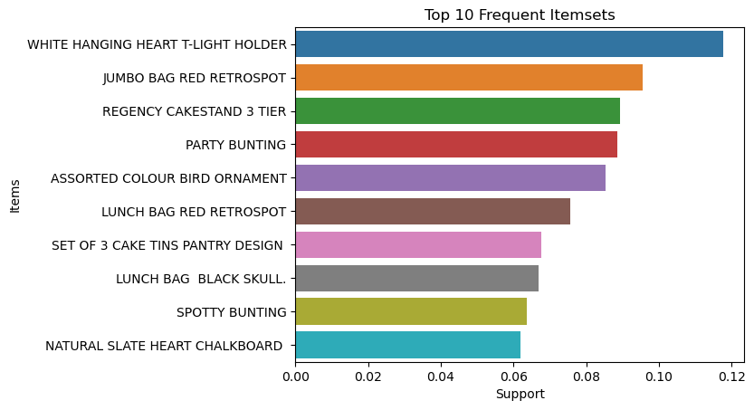

```python
top_itemsets_test = apriori_itemsets_test.sort_values(by='support', ascending=False).head(10)

# Convert itemsets to strings
top_itemsets_test['itemsets'] = top_itemsets_test['itemsets'].apply(lambda x: ', '.join(list(x)))

# Plot bar plot
sns.barplot(x='support', y='itemsets', data=top_itemsets_test)
plt.title('Top 10 Frequent Itemsets')
plt.xlabel('Support')
plt.ylabel('Items')
plt.show()
```

- From the bar plot we can see that the most popular products is WHITE HANGING HEART T-LIGHT HOLDER

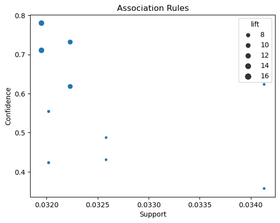

```python
sns.scatterplot(x="support", y="confidence", size="lift", data=apriori_rules_test)
plt.title('Association Rules')
plt.xlabel('Support')
plt.ylabel('Confidence')
plt.show()
```

The scatter plot visually represents the strength of association between products. It depicts the frequency of product pairings alongside the degree of their association, indicating the likelihood of these items being purchased together as a combination.

```python
# Create a DataFrame with lift, antecedents, and consequents
lift_table = pd.DataFrame(columns=['Antecedents', 'Consequents', 'Lift'])

# Populate the DataFrame
for i, rule in apriori_rules_test.iterrows():
    lift_table.loc[i] = [list(rule['antecedents'])[0], list(rule['consequents'])[0],rule['lift']]

# Display the DataFrame
lift_table
```

|  | Antecedents | Consequents | Lift |
| --- | --- | --- | --- |
| 4 | JUMBO BAG RED RETROSPOT | JUMBO BAG PINK POLKADOT | 6.523136 |
| 5 | JUMBO BAG PINK POLKADOT | JUMBO BAG RED RETROSPOT | 6.523136 |
| 6 | LUNCH BAG RED RETROSPOT | LUNCH BAG BLACK SKULL. | 6.442330 |
| 7 | LUNCH BAG BLACK SKULL. | LUNCH BAG RED RETROSPOT | 6.442330 |
| 0 | GARDENERS KNEELING PAD KEEP CALM | GARDENERS KNEELING PAD CUP OF TEA | 14.030302 |
| 1 | GARDENERS KNEELING PAD CUP OF TEA | GARDENERS KNEELING PAD KEEP CALM | 14.030302 |
| 8 | LUNCH BAG PINK POLKADOT | LUNCH BAG RED RETROSPOT | 7.325780 |
| 9 | LUNCH BAG RED RETROSPOT | LUNCH BAG PINK POLKADOT | 7.325780 |
| 2 | ROSES REGENCY TEACUP AND SAUCER | GREEN REGENCY TEACUP AND SAUCER | 17.347068 |
| 3 | GREEN REGENCY TEACUP AND SAUCER | ROSES REGENCY TEACUP AND SAUCER | 17.347068 |

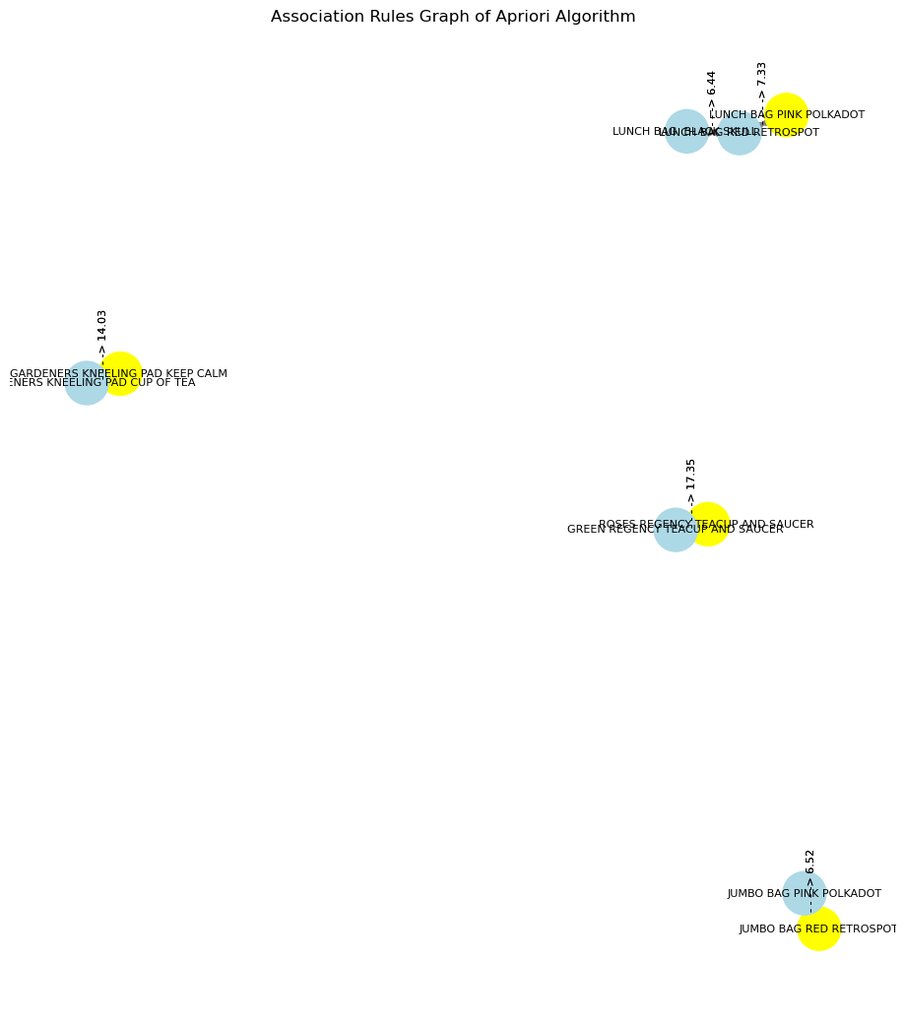

```python
# Create a directed graph
G = nx.DiGraph()

plt.figure(figsize=(9, 10))
# Add nodes for antecedents and consequents
for i, row in lift_table.iterrows():
    G.add_node(row['Antecedents'], color='lightblue')
    G.add_node(row['Consequents'], color='yellow')
    G.add_edge(row['Antecedents'], row['Consequents'], weight=row['Lift'])

    # Draw the graph
pos = nx.spring_layout(G, seed=732)  # Set the seed for reproducibility
nx.draw(G, pos, with_labels=False,node_size=1000, node_color=[color for node, color in nx.get_node_attributes(G, 'color').items()], edge_color='gray', arrowsize=20)

# Add labels for nodes (items) with smaller font size
nx.draw_networkx_labels(G, pos, labels={n: n for n in G.nodes()}, font_size=8)


# Add labels for support and lift below the edges
for edge in G.edges():
    lift = G.edges[(edge[0], edge[1])]['weight']
    x = 0.5 * (pos[edge[0]][0] + pos[edge[1]][0])
    y = 0.5 * (pos[edge[0]][1] + pos[edge[1]][1])
    plt.text(x, y, f"- - - -> {lift:.2f}", fontsize=8, horizontalalignment='center', verticalalignment='bottom', rotation=90)

# Add title
plt.title('Association Rules Graph of Apriori Algorithm')

# Show plot
plt.show()
```

**Insights**

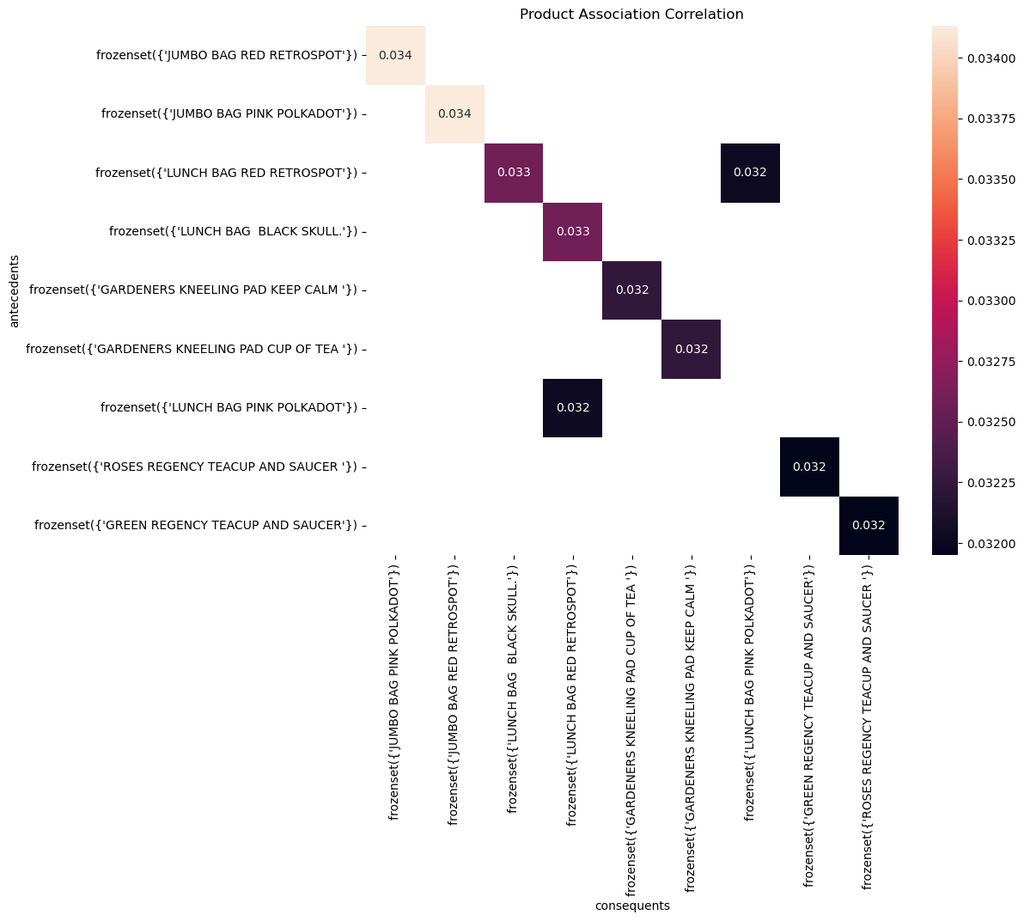

```python
pivot = apriori_rules_test.pivot(index='antecedents', columns='consequents', values='support')
plt.figure(figsize=(10, 8))
sns.heatmap(pivot, annot=True)
plt.title('Product Association Correlation')
plt.show()
```

- Low Support, Low Confidence: These might represent rare but specific co-purchases, reflecting niche market preferences or exceptional buying behaviors.
- High Support, High Confidence: These could represent staple items frequently bought together, forming the backbone of consistent customer purchasing habits.

# Apriori Algorithm min_support=0.01

```python
apriori_itemsets = apriori(filtered_itemset, min_support=0.01,use_colnames=True)
```

```python
apriori_itemsets.sort_values("support", ascending=False)
```

|  | support | itemsets |
| --- | --- | --- |
| 655 | 0.117664 | (WHITE HANGING HEART T-LIGHT HOLDER) |
| 282 | 0.095567 | (JUMBO BAG RED RETROSPOT) |
| 462 | 0.089444 | (REGENCY CAKESTAND 3 TIER) |
| 384 | 0.088459 | (PARTY BUNTING) |
| 40 | 0.085222 | (ASSORTED COLOUR BIRD ORNAMENT) |
| ... | ... | ... |
| 517 | 0.010063 | (SET OF 2 WOODEN MARKET CRATES) |
| 1205 | 0.010063 | (LUNCH BAG DOLLY GIRL DESIGN, LUNCH BAG RED RE... |
| 545 | 0.010063 | (SET OF 6 T-LIGHTS SANTA) |
| 1202 | 0.010063 | (LUNCH BAG PINK POLKADOT, LUNCH BAG SPACEBOY D... |
| 616 | 0.010063 | (TRADTIONAL ALPHABET STAMP SET) |

1233 rows × 2 columns

```python
apriori_itemsets['itemsets'].apply(lambda x: len(x)).value_counts()
```

```
itemsets
1    690
2    415
3    119
4      9
Name: count, dtype: int64
```

- This information reveals that our data primarily contains frequent itemsets with 1 or 2 items. This suggests that customers in online retail store tend to purchase individual items or pairs of items quite frequently.
- The presence of itemsets with 3 and 4 items indicates that some customers might also buy small bundles of products together, but these occurrences are less frequent compared to single items or pairs.

```python
apriori_itemsets['length'] = apriori_itemsets['itemsets'].apply(lambda x: len(x))
```

```python
apriori_itemsets.sort_values(by='support', ascending=False)
```

|  | support | itemsets | length |
| --- | --- | --- | --- |
| 655 | 0.117664 | (WHITE HANGING HEART T-LIGHT HOLDER) | 1 |
| 282 | 0.095567 | (JUMBO BAG RED RETROSPOT) | 1 |
| 462 | 0.089444 | (REGENCY CAKESTAND 3 TIER) | 1 |
| 384 | 0.088459 | (PARTY BUNTING) | 1 |
| 40 | 0.085222 | (ASSORTED COLOUR BIRD ORNAMENT) | 1 |
| ... | ... | ... | ... |
| 517 | 0.010063 | (SET OF 2 WOODEN MARKET CRATES) | 1 |
| 1205 | 0.010063 | (LUNCH BAG DOLLY GIRL DESIGN, LUNCH BAG RED RE... | 3 |
| 545 | 0.010063 | (SET OF 6 T-LIGHTS SANTA) | 1 |
| 1202 | 0.010063 | (LUNCH BAG PINK POLKADOT, LUNCH BAG SPACEBOY D... | 3 |
| 616 | 0.010063 | (TRADTIONAL ALPHABET STAMP SET) | 1 |

1233 rows × 3 columns

```python
apriori_itemsets[apriori_itemsets["length"] > 1]
```

|  | support | itemsets | length |
| --- | --- | --- | --- |
| 690 | 0.010486 | (PACK OF 72 RETROSPOT CAKE CASES, 60 CAKE CASE... | 2 |
| 691 | 0.010415 | (SET OF 20 VINTAGE CHRISTMAS NAPKINS, 60 CAKE ... | 2 |
| 692 | 0.012808 | (72 SWEETHEART FAIRY CAKE CASES, 60 TEATIME FA... | 2 |
| 693 | 0.013863 | (PACK OF 60 DINOSAUR CAKE CASES, 60 TEATIME FA... | 2 |
| 694 | 0.016467 | (PACK OF 60 PINK PAISLEY CAKE CASES, 60 TEATIM... | 2 |
| ... | ... | ... | ... |
| 1228 | 0.010697 | (LUNCH BAG PINK POLKADOT, LUNCH BAG SPACEBOY D... | 4 |
| 1229 | 0.011682 | (LUNCH BAG PINK POLKADOT, LUNCH BAG RED RETROS... | 4 |
| 1230 | 0.010134 | (LUNCH BAG SPACEBOY DESIGN , LUNCH BAG RED RET... | 4 |
| 1231 | 0.010204 | (LUNCH BAG PINK POLKADOT, LUNCH BAG SPACEBOY D... | 4 |
| 1232 | 0.010345 | (LUNCH BAG PINK POLKADOT, LUNCH BAG RED RETROS... | 4 |

543 rows × 3 columns

for this test, we focus on the tems are bought together significantly more often. So I set up the rules with a lift greater than or equal to 20.

```python
apriori_rules = association_rules(apriori_itemsets, metric='lift', min_threshold=20)\
    .sort_values("support",ascending=False)
apriori_rules.describe().T
```

|  | count | mean | std | min | 25% | 50% | 75% | max |
| --- | --- | --- | --- | --- | --- | --- | --- | --- |
| antecedent support | 194.0 | 0.018337 | 0.007182 | 0.010626 | 0.012104 | 0.017030 | 0.021182 | 0.040957 |
| consequent support | 194.0 | 0.018337 | 0.007182 | 0.010626 | 0.012104 | 0.017030 | 0.021182 | 0.040957 |
| support | 194.0 | 0.012090 | 0.003083 | 0.010063 | 0.010486 | 0.010908 | 0.012175 | 0.028290 |
| confidence | 194.0 | 0.714117 | 0.177960 | 0.259897 | 0.583548 | 0.720392 | 0.880774 | 0.973684 |
| lift | 194.0 | 45.953722 | 23.516075 | 20.071372 | 24.964081 | 35.349480 | 76.397849 | 80.442166 |
| leverage | 194.0 | 0.011730 | 0.002877 | 0.009723 | 0.010214 | 0.010698 | 0.011767 | 0.026886 |
| conviction | 194.0 | 6.163265 | 5.761556 | 1.333667 | 2.339025 | 3.501818 | 8.294240 | 37.540042 |
| zhangs_metric | 194.0 | 0.989961 | 0.008779 | 0.962643 | 0.984472 | 0.991559 | 0.998290 | 0.999669 |

We can observe that there are 194 rules generated here.

Next, we will select the top 5 most confidence and the top 5 highest lift levels.

```python
apriori_rules.sort_values(ascending=False,by="confidence").head(5)
```

|  | antecedents | consequents | antecedent support | consequent support | support | confidence | lift | leverage | conviction | zhangs_metric |
| --- | --- | --- | --- | --- | --- | --- | --- | --- | --- | --- |
| 158 | (HERB MARKER MINT, HERB MARKER THYME) | (HERB MARKER ROSEMARY) | 0.010697 | 0.012104 | 0.010415 | 0.973684 | 80.442166 | 0.010286 | 37.540042 | 0.998247 |
| 165 | (HERB MARKER THYME, HERB MARKER PARSLEY) | (HERB MARKER ROSEMARY) | 0.010837 | 0.012104 | 0.010486 | 0.967532 | 79.933932 | 0.010354 | 30.427192 | 0.998309 |
| 140 | (HERB MARKER BASIL, HERB MARKER THYME) | (HERB MARKER ROSEMARY) | 0.010626 | 0.012104 | 0.010274 | 0.966887 | 79.880641 | 0.010146 | 29.834455 | 0.998087 |
| 147 | (HERB MARKER MINT, HERB MARKER PARSLEY) | (HERB MARKER ROSEMARY) | 0.010837 | 0.012104 | 0.010345 | 0.954545 | 78.860994 | 0.010214 | 21.733709 | 0.998137 |
| 128 | (HERB MARKER BASIL, HERB MARKER MINT) | (HERB MARKER ROSEMARY) | 0.010697 | 0.012104 | 0.010204 | 0.953947 | 78.811582 | 0.010075 | 21.451453 | 0.997987 |

Despite the support being approximately 0.01, in this test phase, we will focus on the potential of the items.

- The **top association** reveals that **(HERB MARKER THYME, HERB MARKER MINT) -> HERB MARKER ROSEMARY**: This rule suggests a strong association between thyme, mint, and rosemary, with customers who buy the first two being highly likely (97.37%) to also purchase rosemary (lift: 80.44).
- **(HERB MARKER THYME, HERB MARKER PARSLEY) -> HERB MARKER ROSEMARY**: Similar to the first rule, this indicates a strong association between thyme, parsley, and rosemary (lift: 79.93), with customers buying thyme and parsley likely to also get rosemary (96.75%).

```python
apriori_rules.sort_values(ascending=False,by="lift").head(5)
```

|  | antecedents | consequents | antecedent support | consequent support | support | confidence | lift | leverage | conviction | zhangs_metric |
| --- | --- | --- | --- | --- | --- | --- | --- | --- | --- | --- |
| 163 | (HERB MARKER ROSEMARY) | (HERB MARKER MINT, HERB MARKER THYME) | 0.012104 | 0.010697 | 0.010415 | 0.860465 | 80.442166 | 0.010286 | 7.090007 | 0.999669 |
| 158 | (HERB MARKER MINT, HERB MARKER THYME) | (HERB MARKER ROSEMARY) | 0.010697 | 0.012104 | 0.010415 | 0.973684 | 80.442166 | 0.010286 | 37.540042 | 0.998247 |
| 166 | (HERB MARKER ROSEMARY, HERB MARKER PARSLEY) | (HERB MARKER THYME) | 0.011049 | 0.011823 | 0.010486 | 0.949045 | 80.273355 | 0.010355 | 19.392980 | 0.998575 |
| 167 | (HERB MARKER THYME) | (HERB MARKER ROSEMARY, HERB MARKER PARSLEY) | 0.011823 | 0.011049 | 0.010486 | 0.886905 | 80.273355 | 0.010355 | 8.744413 | 0.999358 |
| 157 | (HERB MARKER PARSLEY) | (HERB MARKER MINT, HERB MARKER THYME) | 0.011752 | 0.010697 | 0.010063 | 0.856287 | 80.051607 | 0.009938 | 6.883902 | 0.999252 |

We have the other interesting when ranked by lift.

> These findings suggest that **thyme, rosemary, and mint** form a strong cluster of frequently bought-together herbs. Customers purchasing any two from this trio are highly likely to also get the third one.

> The **reciprocal nature** of the highlighted rules (rosemary appearing in both top associations and the interesting observation) further strengthens the interconnectedness of these three herbs in your customers' buying patterns.

```python
apriori_rules[apriori_rules['consequents'].apply(lambda x: len(x)) == 3]
```

|  | antecedents | consequents | antecedent support | consequent support | support | confidence | lift | leverage | conviction | zhangs_metric |
| --- | --- | --- | --- | --- | --- | --- | --- | --- | --- | --- |
| 193 | (PINK REGENCY TEACUP AND SAUCER) | (ROSES REGENCY TEACUP AND SAUCER , GREEN REGEN... | 0.034272 | 0.017593 | 0.014215 | 0.414784 | 23.576345 | 0.013612 | 1.678709 | 0.991567 |
| 192 | (GREEN REGENCY TEACUP AND SAUCER) | (ROSES REGENCY TEACUP AND SAUCER , REGENCY CAK... | 0.040957 | 0.015834 | 0.014215 | 0.347079 | 21.919969 | 0.013567 | 1.507328 | 0.995137 |

```python
apriori_rules[apriori_rules['consequents'].apply(lambda x: len(x)) == 3]["consequents"].values
```

```
array([frozenset({'ROSES REGENCY TEACUP AND SAUCER ', 'GREEN REGENCY TEACUP AND SAUCER', 'REGENCY CAKESTAND 3 TIER'}),
       frozenset({'ROSES REGENCY TEACUP AND SAUCER ', 'REGENCY CAKESTAND 3 TIER', 'PINK REGENCY TEACUP AND SAUCER'})],
      dtype=object)
```

- These rules reveal that customers purchasing a specific color teacup and saucer are likely to also purchase the other two color variations of the same design (pink, green, and roses) and a matching cake stand.
- Both rules have high lift values (significantly higher than 1), indicating a strong association between these items beyond mere chance. While the confidence values differ slightly, they still suggest a considerable likelihood of customers buying the entire set.

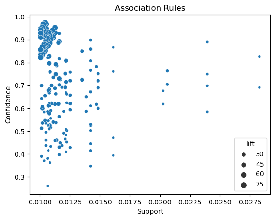

```python
sns.scatterplot(x="support", y="confidence", size="lift", data=apriori_rules)
plt.title('Association Rules')
plt.xlabel('Support')
plt.ylabel('Confidence')
plt.show()
```

## Top 10 items most likely to be bought along with specific items

### "HERB MARKER ROSEMARY" item

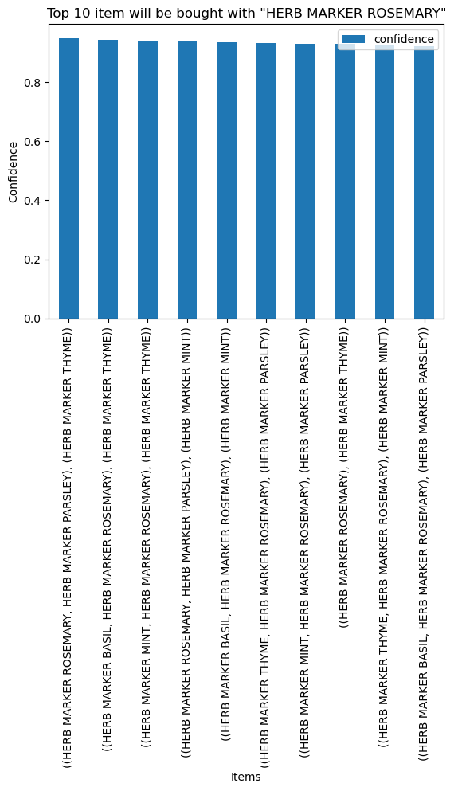

```python
# Filter rules where "HERB MARKER ROSEMARY" is in the antecedents
filtered_rules = apriori_rules[apriori_rules["antecedents"].apply(lambda x: "HERB MARKER ROSEMARY" in str(x))]

# Group by antecedents and consequents, then find maximum confidence
grouped_rules = filtered_rules.groupby(['antecedents', 'consequents'])[['confidence']].max()

# Sort values by confidence in descending order and select top 10
top_10_rules = grouped_rules.sort_values(by='confidence', ascending=False).head(10)

# Plot as a vertical bar chart and transpose
top_10_rules.plot(kind='bar', rot=90)  # Rotate x-axis labels by 90 degrees
plt.title('Top 10 item will be bought with "HERB MARKER ROSEMARY"')
plt.xlabel('Items')
plt.ylabel('Confidence')
plt.show()
```

The specific items displayed on the x-axis will reveal those with the highest confidence scores for being purchased alongside "HERB MARKER ROSEMARY".

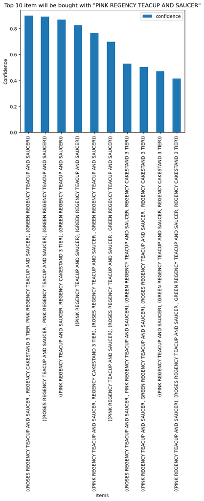

```python
# Filter rules where "LUNCH BAG SPACEBOY DESIGN " is in the antecedents
filtered_rules1 = apriori_rules[apriori_rules["antecedents"].apply(lambda x: "PINK REGENCY TEACUP AND SAUCER" in str(x))]

# Group by antecedents and consequents, then find maximum confidence
grouped_rules1 = filtered_rules1.groupby(['antecedents', 'consequents'])[['confidence']].max()

# Sort values by confidence in descending order and select top 10
top_10_rules1 = grouped_rules1.sort_values(by='confidence', ascending=False).head(10)

# Plot as a vertical bar chart and transpose
top_10_rules1.plot(kind='bar')
plt.title('Top 10 item will be bought with "PINK REGENCY TEACUP AND SAUCER"')
plt.xlabel('Items')
plt.ylabel('Confidence')
plt.show()
```

**Recommendation**

- **Product recommendations**: Recommend these items to customers who are viewing or have added items is "HERB MARKER ROSEMARY" or "PINK REGENCY TEACUP AND SAUCER" to their cart.
- **Product placement**: Position these items together in physical stores or online to encourage shoppers to buy them as a bundle.
- **Targeted promotions**: Offer discounts or special deals on these items when customers purchase the herb marker.

## Visulizing Association rules

### Networkx

An intriguing approach to analyzing such data involves utilizing network analysis plots to visualize the relationships between each feature and its corresponding compound feature within the dataset. In this case, we employed the NetworkX module to plot the top 100 strongest relations.

```python
apriori_rules['antecedents'] = apriori_rules.antecedents.apply(lambda x: next(iter(x)))
apriori_rules['consequents'] = apriori_rules.consequents.apply(lambda x: next(iter(x)))
```

```python
import networkx as nx
import warnings
import matplotlib.pyplot as plt

warnings.filterwarnings('ignore')
plt.style.use('fivethirtyeight')

# Filter the top 100 association rules based on lift
top_100_rules = apriori_rules.sort_values(by='lift', ascending=False).head(100)

# Create the graph
edges = nx.from_pandas_edgelist(top_100_rules, source='antecedents', target='consequents', edge_attr=None)

# Plot the graph
plt.subplots(figsize=(60, 80))
plt.suptitle('Top 100 association rules based on lift', fontsize=50, fontweight='bold')
pos = nx.spring_layout(edges)  # You can choose a layout based on your preference
nx.draw_networkx_nodes(edges, pos, node_size=2000, alpha=0.7, node_color='tomato')
nx.draw_networkx_edges(edges, pos, width=6, alpha=0.2, edge_color='indigo')
nx.draw_networkx_labels(edges, pos, font_size=43, font_weight='bold')
plt.grid()
plt.axis('off')
plt.tight_layout()
plt.show()
```

[output not shown]

# Conclusion

This project underscores the transformative potential of association rule mining in uncovering latent connections and patterns within complex datasets:

- **Illuminating hidden relationships**: Through association rule mining, our analysis has unearthed surprising correlations between seemingly unrelated products. Notably, the strong associations identified among specific teacup variations and the "HERB MARKER" products highlight the capacity of this methodology to reveal previously unseen connections in customer purchasing behavior.
  - *Teacup and saucer sets*: Customers purchasing a single teacup and saucer are likely to buy the other two color variations and a matching cake stand.
  - *Herbs*: Thyme, rosemary, and mint form a strong cluster, with customers buying any two from this trio highly likely to also purchase the third one.
- **Revealing product clusters**: Our findings elucidate the clustering phenomenon evident in the association rules, such as the emergence of distinct product clusters like the "herbs trio" comprising thyme, rosemary, and mint. These insights offer valuable insights into underlying product categories and customer preferences, providing a deeper understanding of consumer behavior and preferences.
- **Driving actionable strategies**: Importantly, our analysis extends beyond mere observation by translating discovered associations into actionable insights for business strategies. Recommendations for targeted marketing, strategic product placement, and customer engagement strategies underscore the practical utility of these findings in optimizing sales performance and enhancing customer satisfaction.

# Future Work

**Temporal patterns exploration**: Investigate temporal patterns in customer purchasing behavior, including seasonal fluctuations. By analyzing how buying patterns evolve over time, we can gain insights into time-sensitive associations and adjust marketing strategies accordingly to capitalize on seasonal trends.

**Network analysis refinement**: Further refine network analysis methodologies to uncover more intricate relationships between product categories. By delving deeper into network analysis, we can uncover hidden patterns in customer behavior and better understand the underlying dynamics driving purchasing decisions.

**Implementation of recommendations**: Build upon the identified associations to implement actionable strategies derived from these insights. This involves deploying targeted product recommendations and strategic product placement initiatives to influence customer purchasing behavior. Testing these strategies in real-world settings will allow us to validate their effectiveness and refine our approach to optimize business outcomes.

# Reference

- Han, J., Pei, J., & Kamber, M. (2011). *Data Mining: Concepts and Techniques* (3rd ed.). Elsevier.
- Aggarwal, C. C., & Yu, P. S. (2019). *A Survey of Frequent Itemset Mining Algorithms*. arXiv preprint arXiv:1902.10999.
- Agrawal, R., & Srikant, R. (1994). *Fast algorithms for mining association rules*. In Proceedings of the 20th International Conference on Very Large Data Bases (VLDB) , 487-499.